# GEOG456_P1_BikeCrash

Mia Colloredo-Mansfeld

1/29/2020

## Temporal Data Visualization

This tutorial walks thorugh producing a visual using temporal data. The data is from the NCDOT and includes 60 variables about bike-motor vehicle crashes in North Carolina from 2001-2018.

The first step is importing the data.

```r
the_file<- "/Users/miacm/Documents/Spring_2020/GEGO_456/Project1/NCDOT_Bike_Crash_Data_fixed2.csv" #this identifies the location of the data on your computer, copy the pathname to direct r to the location of the saved data.
df<- read.csv (the_file) #opens csv file
```

## Understanding the data

To figure out interesting variables to explore further, we can make some simple frequency tables:

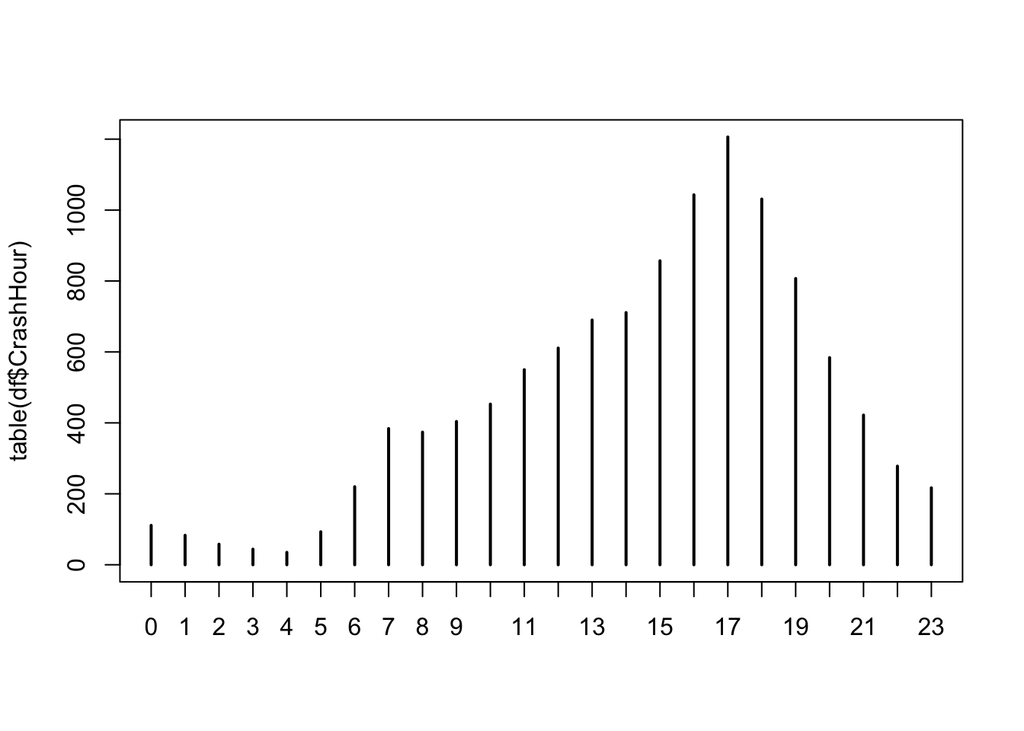

```r
plot(table(df$CrashHour)) #plots the frequency of crashes each hour using the CrashHour variable
```

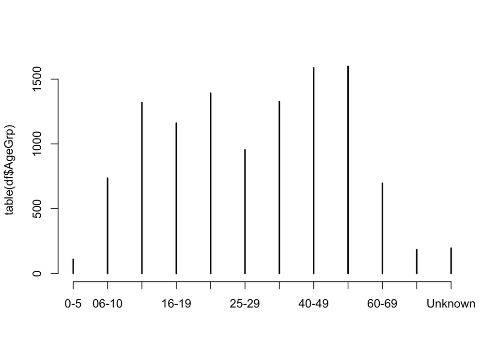

```r
plot(table(df$AgeGrp)) #plots the frequency of crashes in each agegroup using the AgeGrp variable
```

## Making prettier plots

Now that we have a better sense for what some of our data looks like, we want to make it look better. To do this, we need to import a few libraries.

```r
library(ggplot2) #this opens the ggplot2 library
library(ggridges) #this opens the ggridges library
library(RColorBrewer) #this opens the RColorBrewer library
```

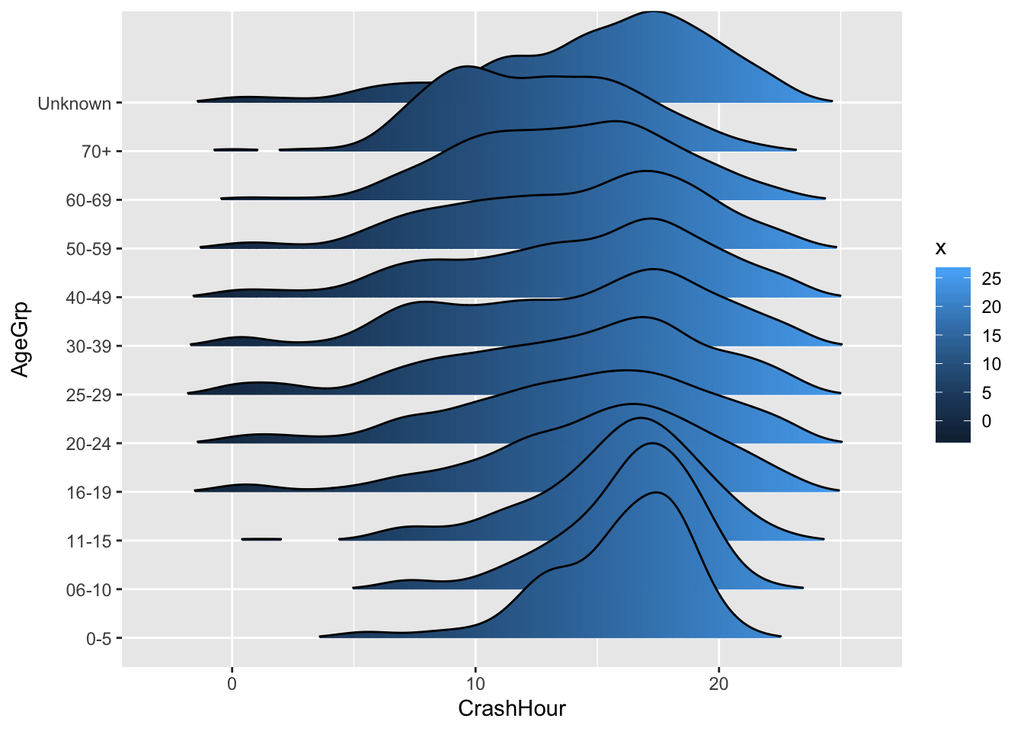

```r
ggplot(df, aes(x = CrashHour, y = AgeGrp, fill = ..x..)) +
  geom_density_ridges_gradient(scale = 3, rel_min_height = 0.01)
```

```r
#This will produce a plot with CrashHour along the x axis and AgeGrp along the Y axis.
```

We want to pick colors that better portray our data. We will use color brewer to do that.

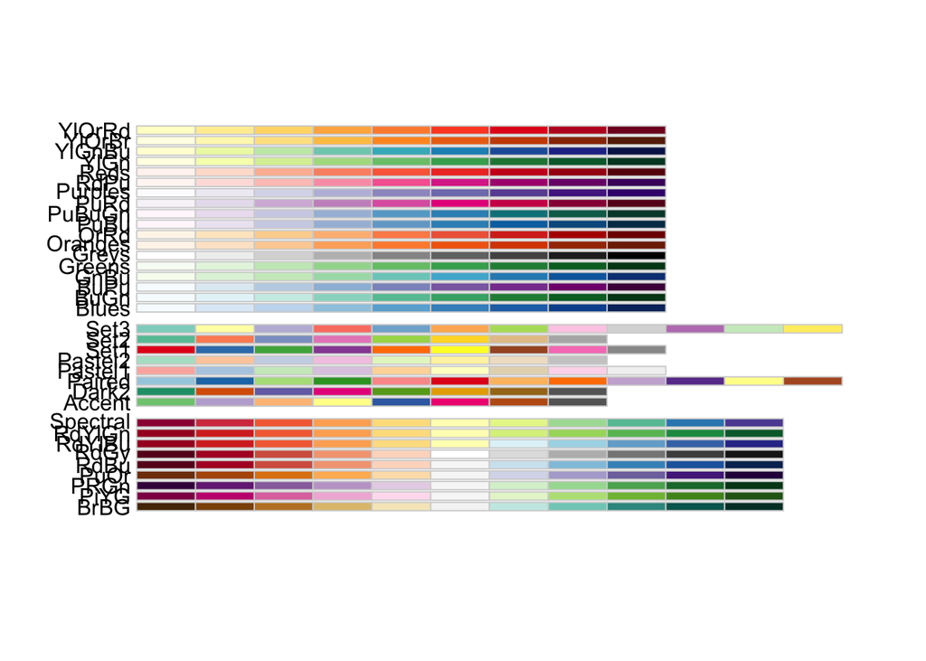

```r
display.brewer.all() #Shows all the color gradients we can pick from
```

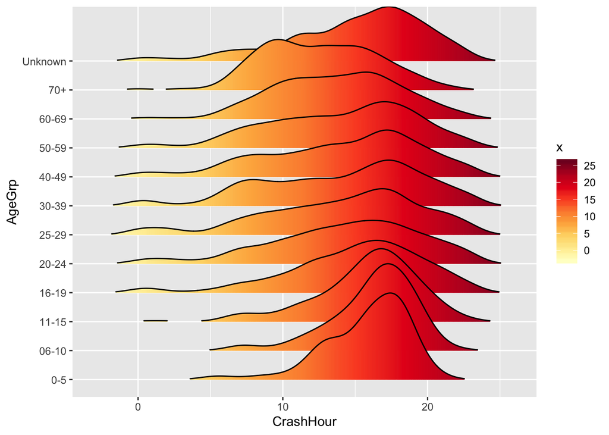

```r
ggplot(df, aes(x = CrashHour, y = AgeGrp, fill = ..x..)) + geom_density_ridges_gradient(scale = 3, rel_min_height = 0.01)+ scale_fill_gradientn(colours=colorRampPalette((brewer.pal(9,"YlOrRd")))(100)) #This changes the colors to our color gradient of choice
```

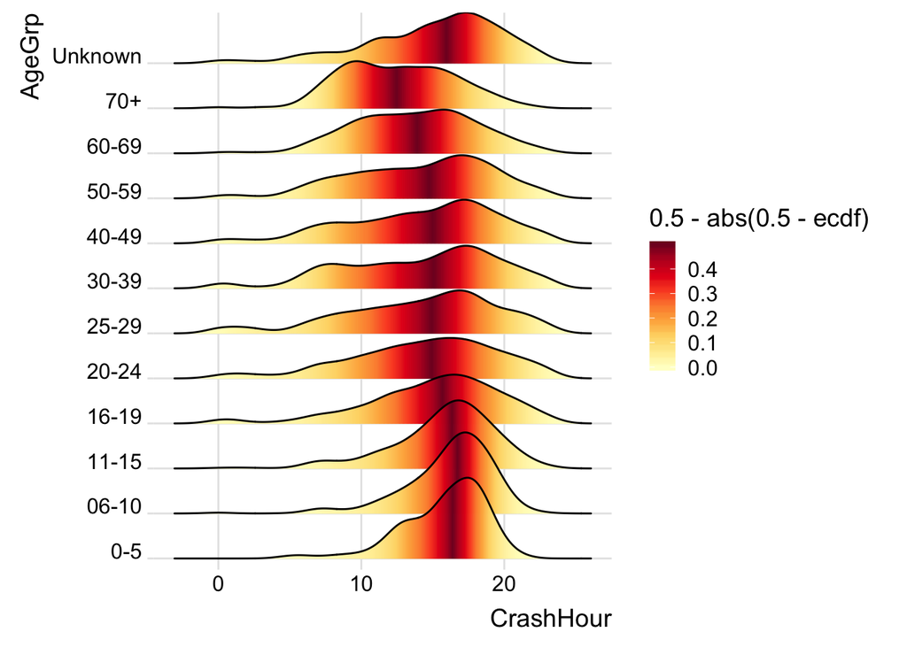

```r
ggplot(df, aes(x=CrashHour, y=AgeGrp, fill=0.5 - abs(0.5-..ecdf..))) + stat_density_ridges(geom = "density_ridges_gradient",calc_ecdf = TRUE)+ scale_fill_gradientn(colours = colorRampPalette((brewer.pal(9,"YlOrRd")))(100)) +theme_ridges() + scale_y_discrete(expand = c(0.01, 0)) #Now the color gradient reflects the mean crash hour for each age group
```

We can also add a title, adjust the scale on the x-axis, and change the names of the x and y axes.

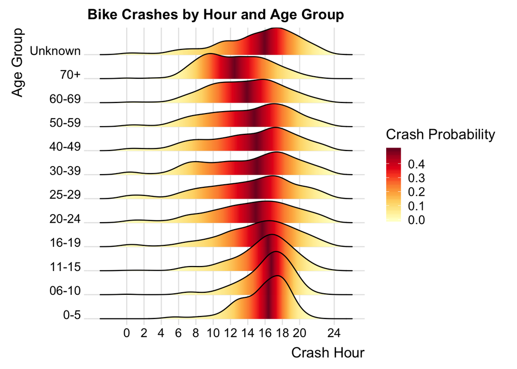

```r
ggplot(df, aes(x=CrashHour, y=AgeGrp, fill=0.5 - abs(0.5-..ecdf..))) + stat_density_ridges(geom = "density_ridges_gradient", calc_ecdf = TRUE)+ scale_fill_gradientn(name = "Crash Probability", colours = colorRampPalette((brewer.pal(9,"YlOrRd")))(100)) + theme_ridges() + scale_y_discrete(expand = c(0.01, 0)) + scale_x_continuous(breaks=c(0, 2, 4, 6, 8, 10, 12, 14, 16, 18, 20, 24)) + labs(title = 'Bike Crashes by Hour and Age Group', x = "Crash Hour", y="Age Group") #We added code to change the names of our axes and to adjust the x-axis scale.
```